# Density-Based Clustering with DBSCAN

Unsupervised Learning, Density-Based Clustering, Core Points, Border Points, Noise/Outliers, Epsilon (ε), MinPts (Minimum Points), Arbitrarily Shaped Clusters.

### **Objectives:**

- Students will understand the limitations of centroid-based clustering algorithms like K-Means when dealing with **non-spherical clusters** or **outliers**.
- Students will grasp the core, density-based concepts of DBSCAN: **core points**, **border points**, and **noise points**.
- Students will understand the two critical hyperparameters—**`eps`** (Epsilon) and **`min_samples`** (MinPts)—and their influence on the clustering outcome.
- Students will implement the DBSCAN algorithm using `scikit-learn`.
- Students will learn and apply a practical heuristic (the **k-distance graph**) for choosing an optimal `eps` value.
- Students will visualize and interpret DBSCAN results, including its ability to identify arbitrarily shaped clusters and correctly label noise points.

### **Setup: Install and Import Libraries**

```python
# No special installs are needed
# Import libraries
import pandas as pd
import numpy as np
import matplotlib.pyplot as plt
import seaborn as sns
import sklearn

# Scikit-learn for clustering, datasets, and preprocessing
from sklearn.preprocessing import StandardScaler
from sklearn.cluster import DBSCAN, KMeans
from sklearn.datasets import make_moons, make_circles
from sklearn.neighbors import NearestNeighbors

# Set plot style for better aesthetics
sns.set_theme(style="whitegrid")
sns.set_context("notebook", font_scale=1.2)


# Suppress warnings for cleaner output
import warnings
warnings.filterwarnings('ignore')

print(f"Pandas Version: {pd.__version__}")
print(f"Scikit-learn Version: {sklearn.__version__}")
```

```
Pandas Version: 2.2.2
Scikit-learn Version: 1.6.1
```

### **Part 1: The Weakness of K-Means & The Need for DBSCAN**

Centroid-based algorithms like **K-Means** work by partitioning data into a pre-specified number of spherical "blobs." This works well for data that is naturally grouped this way, but it fails on more complex structures. K-Means will attempt to force-fit its spherical clusters onto any data shape and is sensitive to outliers, as every point *must* be assigned to a cluster.

Let's demonstrate this failure on a dataset where the true clusters are non-spherical.

```
--- Part 1: Demonstrating the Failure of K-Means ---
```

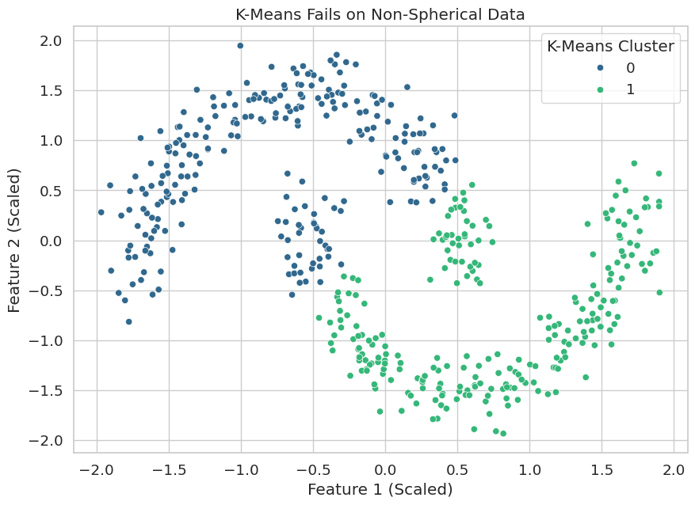

```python
print("--- Part 1: Demonstrating the Failure of K-Means ---")

# 1. Generate a non-spherical dataset (moons) with some noise
X, y = make_moons(n_samples=500, noise=0.1, random_state=42)
X_scaled = StandardScaler().fit_transform(X)

# 2. Apply K-Means with k=2
kmeans = KMeans(n_clusters=2, random_state=42, n_init=10)
kmeans_labels = kmeans.fit_predict(X_scaled)

# 3. Visualize the K-Means result
plt.figure(figsize=(10, 7))
sns.scatterplot(x=X_scaled[:, 0], y=X_scaled[:, 1], hue=kmeans_labels, palette='viridis')
plt.title('K-Means Fails on Non-Spherical Data')
plt.xlabel('Feature 1 (Scaled)')
plt.ylabel('Feature 2 (Scaled)')
plt.legend(title='K-Means Cluster')
plt.show()

# INSIGHT: K-Means fails completely. It incorrectly splits each "moon" in half, unable to capture the true crescent-shaped clusters.
# This motivates the need for a different approach that doesn't assume a cluster shape.
```

### **Part 2: Core Concepts of DBSCAN**

**DBSCAN (Density-Based Spatial Clustering of Applications with Noise)** defines clusters as continuous regions of high density. It is governed by two simple concepts:

1. **`eps` (Epsilon, ε)**: The radius of a neighborhood. If you draw a circle with radius `eps` around a data point, all points inside that circle are its neighbors.
2. **`min_samples` (MinPts)**: The minimum number of points required inside a point's `eps`-neighborhood for that point to be considered a **core point**.

Based on these parameters, every point in the dataset is classified as one of three types:

- **Core Point**: A point that has at least `min_samples` neighbors (including itself) within its `eps` radius. These points are the "hearts" of a cluster.
- **Border Point**: A point that is within the `eps` radius of a core point but does not have enough neighbors to be a core point itself. These are the "edges" of a cluster.
- **Noise Point (Outlier)**: Any point that is neither a core nor a border point. These points are isolated in low-density regions.

The algorithm works by picking a point, checking if it's a core point, and if so, expanding a cluster from it and all its density-reachable neighbors.